# Normalization of the Mass Spec Data

Kacper Kaszuba

2024-09-25

# Load Data

```r
# non-imputed data
lfq <- read.csv('./data/nonimputed_lfq.csv')
knitr::kable(head(lfq), format='html')
```

| KO.22 | KO.23 | KO.24 | WT.22 | WT.23 | WT.24 |
| --- | --- | --- | --- | --- | --- |
| NA | NA | NA | NA | NA | NA |
| NA | NA | NA | NA | NA | NA |
| NA | NA | NA | NA | NA | NA |
| NA | NA | NA | NA | NA | NA |
| NA | NA | 23.19647 | NA | 22.0022 | NA |
| 23.88101 | 23.58256 | 26.41355 | 24.2097 | 23.2863 | 23.16521 |

```r
# imputed data
lfq_imp <- read.csv('./data/LFQ_raw_totals_imp.csv')
colnames(lfq_imp) <- gsub('_TOTALS_', '.I.', colnames(lfq_imp))
knitr::kable(head(lfq_imp), format='html')
```

| KO.I.22 | KO.I.23 | KO.I.24 | WT.I.22 | WT.I.23 | WT.I.24 |
| --- | --- | --- | --- | --- | --- |
| 22.44817 | 22.44805 | 23.05376 | 22.45849 | 22.39561 | 22.39090 |
| 22.24563 | 22.24258 | 22.86036 | 22.25553 | 22.18766 | 22.18389 |
| 20.06529 | 20.03072 | 20.77835 | 20.07056 | 19.94892 | 19.95532 |
| 21.54988 | 21.53677 | 22.19598 | 21.55829 | 21.47326 | 21.47274 |
| 21.92025 | 21.91249 | 23.19647 | 21.92945 | 22.00220 | 21.85130 |
| 23.88101 | 23.58256 | 26.41355 | 24.20970 | 23.28630 | 23.16521 |

# Data Preparation

```r
# Extracting only TOTALS data for knockout
LFQ_KO <- lfq %>% select(contains('KO'))

# Extracting only TOTALS data for wild type
LFQ_WT <- lfq %>% select(contains('WT'))
```

```r
# Extracting only TOTALS data for knockout
LFQ_KO_imp <- lfq_imp %>% select(contains('KO'))

# Extracting only TOTALS data for wild type
LFQ_WT_imp <- lfq_imp %>% select(contains('WT'))
```

# Data Mining

First of all, we have to check the distribution of our data.

## Knockout

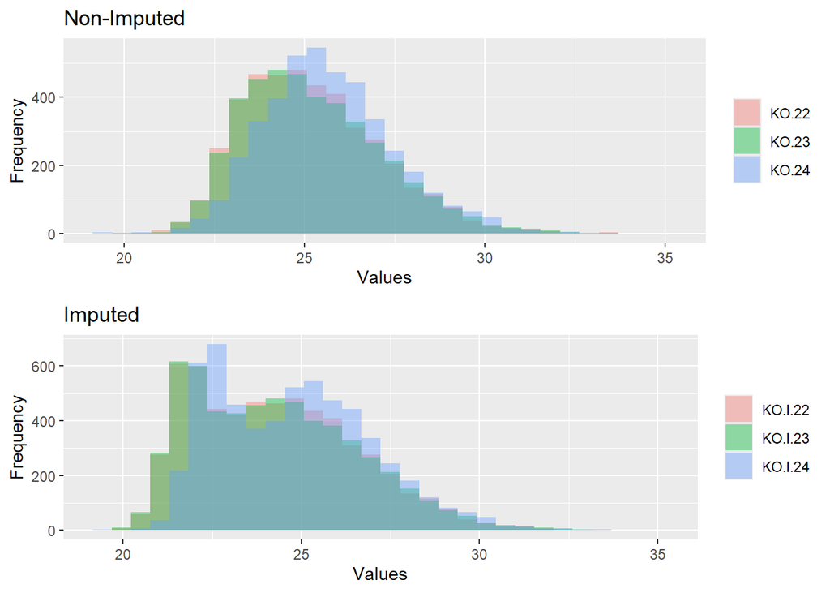

```r
ggarrange(
    plothist(LFQ_KO, 'Non-Imputed'),
    plothist(LFQ_KO_imp, 'Imputed'),
    nrow = 2, ncol = 1
)
```

As we see on the historam of konckout columns, the data are slightly skewed to the right.

```r
moments::skewness(cbind(LFQ_KO,LFQ_KO_imp), na.rm=TRUE)
```

```
##     KO.22     KO.23     KO.24   KO.I.22   KO.I.23   KO.I.24
## 0.6754195 0.6725489 0.5218363 0.5761698 0.5868388 0.5206581
```

The asymmetry score tells use that we need to make some transformation of our data and confirms the conclusions drawn from the histogram.

## Wild type

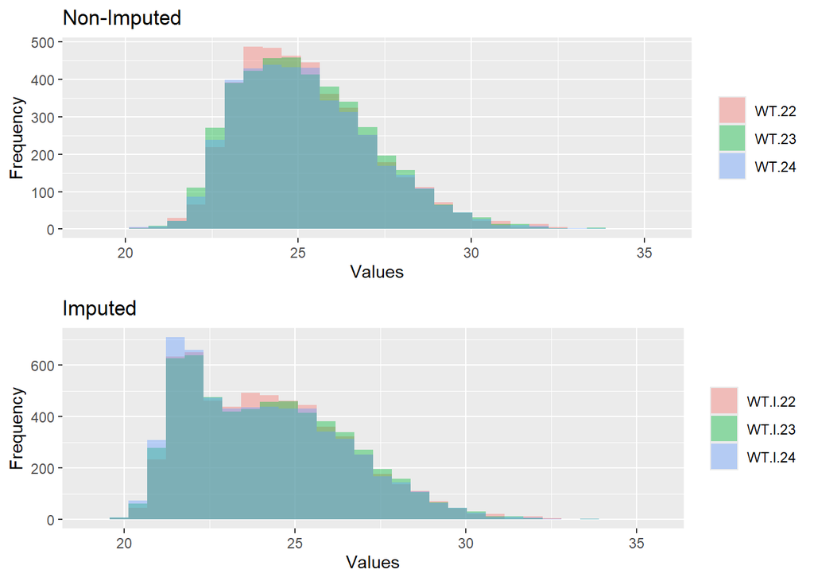

```r
ggarrange(
    plothist(LFQ_WT, 'Non-Imputed'),
    plothist(LFQ_WT_imp, 'Imputed'),
    nrow = 2, ncol = 1
)
```

As we see on the historam of wild type columns, the data are slightly skewed to the right.

```r
moments::skewness(cbind(LFQ_WT,LFQ_WT_imp), na.rm=TRUE)
```

```
##     WT.22     WT.23     WT.24   WT.I.22   WT.I.23   WT.I.24
## 0.7211065 0.6383786 0.7043256 0.6285968 0.5813767 0.6579983
```

The asymmetry score tells use that we have to make some transformation of our data and confirms the conclusions drawn from the histogram.

# Transformation - KO

Based on the graphic below, we will first use the natural logarithm.

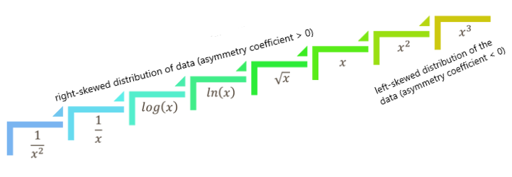

## Logarithm

```r
LFQ_KO.log <- log(LFQ_KO) # Non-Imputed
LFQ_KO_imp.log <- log(LFQ_KO_imp) # Imputed
```

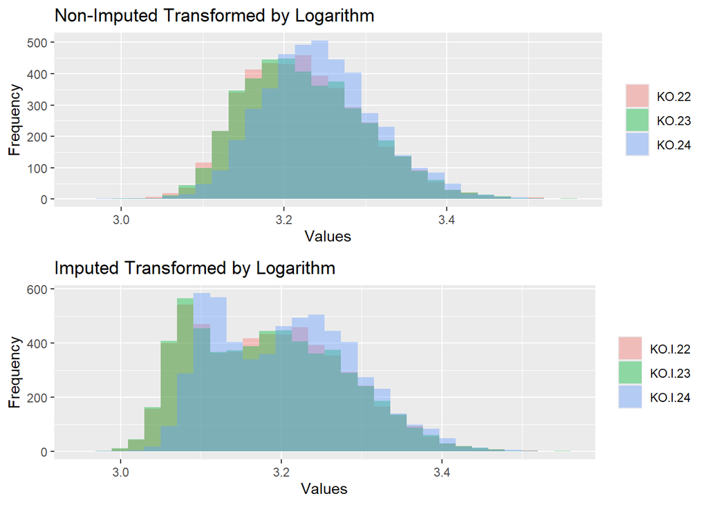

The data distributions looks better, but they are still skewed to the right side.

```r
moments::skewness(cbind(LFQ_KO.log,LFQ_KO_imp.log), na.rm=TRUE)
```

```
##     KO.22     KO.23     KO.24   KO.I.22   KO.I.23   KO.I.24
## 0.4538071 0.4538777 0.2723878 0.3737451 0.3857815 0.3298938
```

The skewness score is smaler. This is good, but check another transformation.

## Fraction $1/x$

```r
LFQ_KO.frac <- 1/LFQ_KO # Non-Imputed
LFQ_KO_imp.frac <- 1/LFQ_KO_imp # Imputed
```

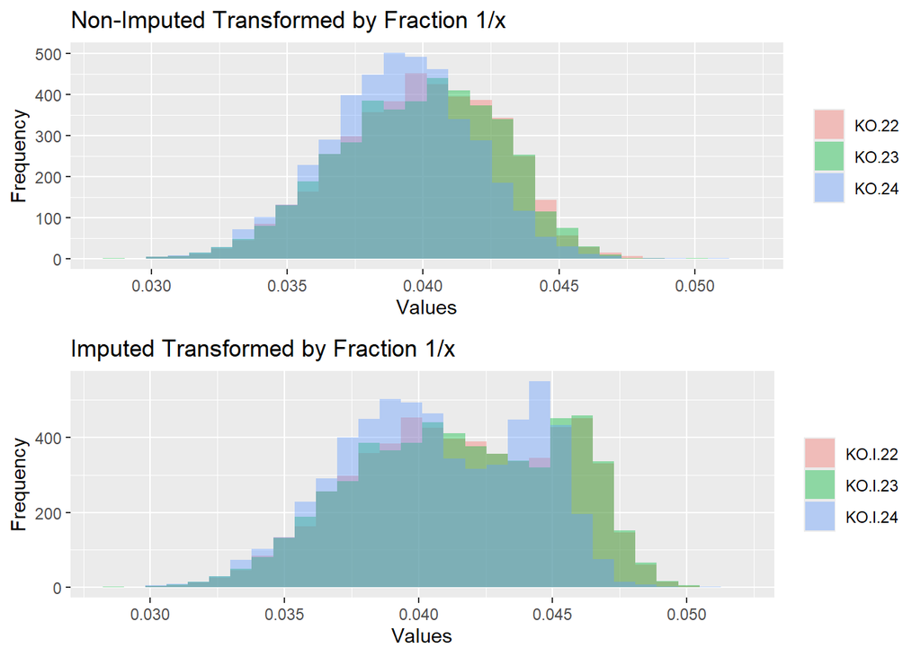

```r
moments::skewness(cbind(LFQ_KO.frac, LFQ_KO_imp.frac), na.rm=TRUE)
```

```
##       KO.22       KO.23       KO.24     KO.I.22     KO.I.23     KO.I.24
## -0.24799683 -0.24994581 -0.02267739 -0.19230177 -0.20508428 -0.15637524
```

As we see above the plot and scores of the skewness aren’t close to normal distribution. Our result shows us that with simple transformation we can’t transform data and make their distribution closer to the Gaussian.

## Box-Cox Transformation

The transformation is based on the formula:

$$x' = \Bigg\{
\matrix{\frac{x^{\lambda}-1}{\lambda} & \lambda \neq0 \\
log(x) & \lambda = 0}$$

```r
### Non-Imputed ###
# At first we have to calculate the lambda
lambda.22 <- car::powerTransform(LFQ_KO$KO.22)$lambda
lambda.23 <- car::powerTransform(LFQ_KO$KO.23)$lambda
lambda.24 <- car::powerTransform(LFQ_KO$KO.24)$lambda
```

|  | lambda.22 | lambda.23 | lambda.24 |
| --- | --- | --- | --- |
| lambda | -2.189341 | -2.194566 | -1.129241 |

The lambda is not 0, so the first transformation is performed.

```r
LFQ_KO.boxcox.22 <- car::bcPower(LFQ_KO$KO.22, lambda.22)
LFQ_KO.boxcox.23 <- car::bcPower(LFQ_KO$KO.23, lambda.23)
LFQ_KO.boxcox.24 <- car::bcPower(LFQ_KO$KO.24, lambda.24)
LFQ_KO.boxcox <- data.frame(LFQ_KO.boxcox.22, LFQ_KO.boxcox.23, LFQ_KO.boxcox.24)
colnames(LFQ_KO.boxcox) <- c('KO.22', 'KO.23', 'KO.24')
```

```r
### Imputed ###
# At first we have to calculate the lambda
lambda.22 <- car::powerTransform(LFQ_KO_imp$KO.I.22)$lambda
lambda.23 <- car::powerTransform(LFQ_KO_imp$KO.I.23)$lambda
lambda.24 <- car::powerTransform(LFQ_KO_imp$KO.I.24)$lambda
```

|  | lambda.22 | lambda.23 | lambda.24 |
| --- | --- | --- | --- |
| lambda | -1.870607 | -1.929126 | -1.727173 |

The lambda is not 0, so the first transformation is performed.

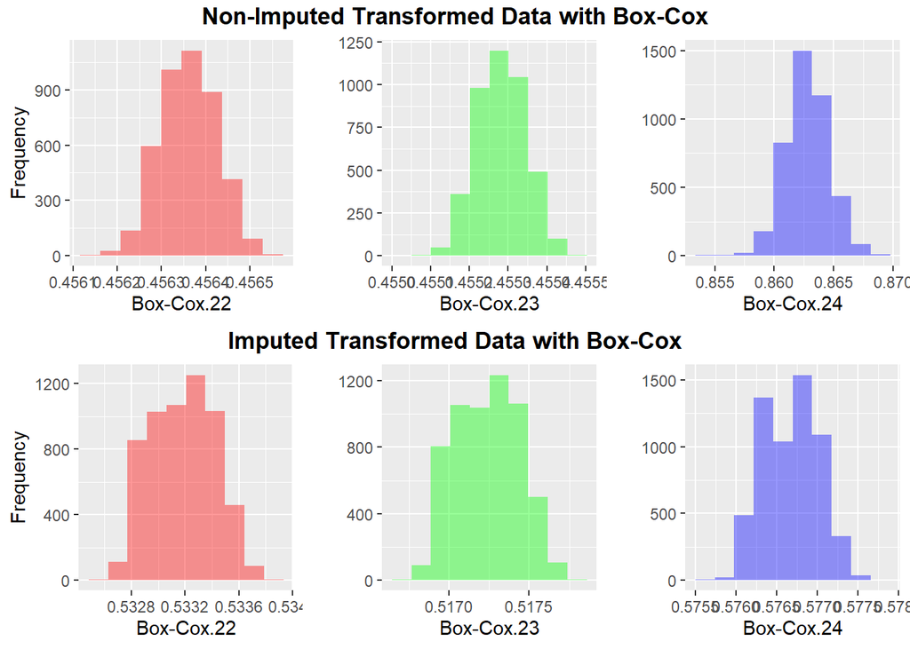

```r
LFQ_KO.boxcox.22 <- car::bcPower(LFQ_KO_imp$KO.I.22, lambda.22)
LFQ_KO.boxcox.23 <- car::bcPower(LFQ_KO_imp$KO.I.23, lambda.23)
LFQ_KO.boxcox.24 <- car::bcPower(LFQ_KO_imp$KO.I.24, lambda.24)
LFQ_KO_imp.boxcox <- data.frame(LFQ_KO.boxcox.22, LFQ_KO.boxcox.23, LFQ_KO.boxcox.24)
colnames(LFQ_KO_imp.boxcox) <- c('KO.I.22', 'KO.I.23', 'KO.I.24')
```

```r
moments::skewness(cbind(LFQ_KO.boxcox, LFQ_KO_imp.boxcox), na.rm=TRUE)
```

```
##       KO.22       KO.23       KO.24     KO.I.22     KO.I.23     KO.I.24
##  0.01691875  0.01817077 -0.01003888  0.04771938  0.05134458  0.03856700
```

Finally we have got expected results. The distributions are similar to a normal distribution. 🎉

# Normalization - KO

## Z-score Normalization

Z-score normalization standardizes data by subtracting the mean and dividing by the standard deviation. This technique transforms data into a distribution with a mean of 0 and a standard deviation of 1.

Formula: $\tilde{y}_{ij} = \frac{y_ij - \bar{y_j}}{\theta_j}$, where:

- $y_ij$ - value of the LFQ;
- $\bar{y_j}$ - mean of the LFQ values;
- $\theta_j$ - standard deviation of the LFQ values.

```r
LFQ_KO.standard <- as.data.frame(scale(LFQ_KO)) # Non-Imputed
LFQ_KO_imp.standard <- as.data.frame(scale(LFQ_KO_imp)) # Imputed
```

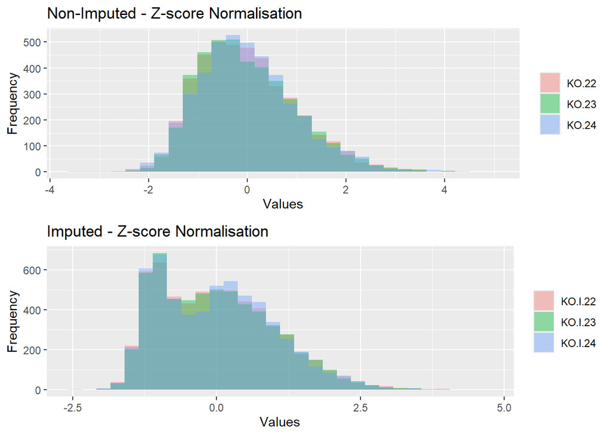

```r
moments::skewness(cbind(LFQ_KO.standard, LFQ_KO_imp.standard), na.rm=TRUE)
```

```
##     KO.22     KO.23     KO.24   KO.I.22   KO.I.23   KO.I.24
## 0.6754195 0.6725489 0.5218363 0.5761698 0.5868388 0.5206581
```

Unfortunately the standardization didn’t help to bring the distribution closer to the normal dist.

## Min-max Normalization

Min-max normalization scales data to a specified range (usually [0, 1]) by subtracting the minimum value and dividing by the range of values.

```r
min_max_norm <- function(df) {
    df_no_na <- na.omit(df)
    ret <- scale(df_no_na, center = min(df_no_na), scale = max(df_no_na) - min(df_no_na))
    df[which(!is.na(df))] <- ret
    return(df)
}

LFQ_KO.minmax <- as.data.frame(lapply(LFQ_KO, function(col) min_max_norm(col)))  # Non-Imputed
LFQ_KO_imp.minmax <- as.data.frame(lapply(LFQ_KO_imp, function(col) min_max_norm(col)))  # Imputed
```

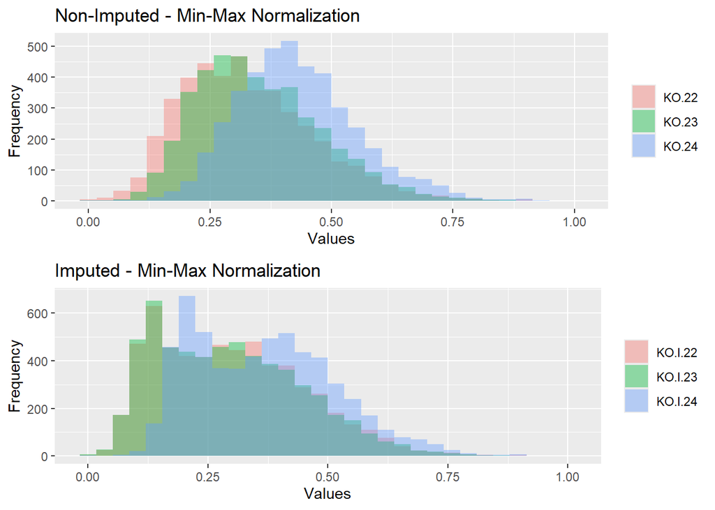

```r
moments::skewness(cbind(LFQ_KO.minmax, LFQ_KO_imp.minmax), na.rm=TRUE)
```

```
##     KO.22     KO.23     KO.24   KO.I.22   KO.I.23   KO.I.24
## 0.6754195 0.6725489 0.5218363 0.5761698 0.5868388 0.5206581
```

Unfortunately, again the normalization didn’t help. 😒

## Median Scaling

```r
LFQ_KO.med <- as.data.frame(DescTools::RobScale(LFQ_KO, scale=FALSE)) # Non-Imputed
LFQ_KO_imp.med <- as.data.frame(DescTools::RobScale(LFQ_KO_imp, scale=FALSE)) # Imputed
```

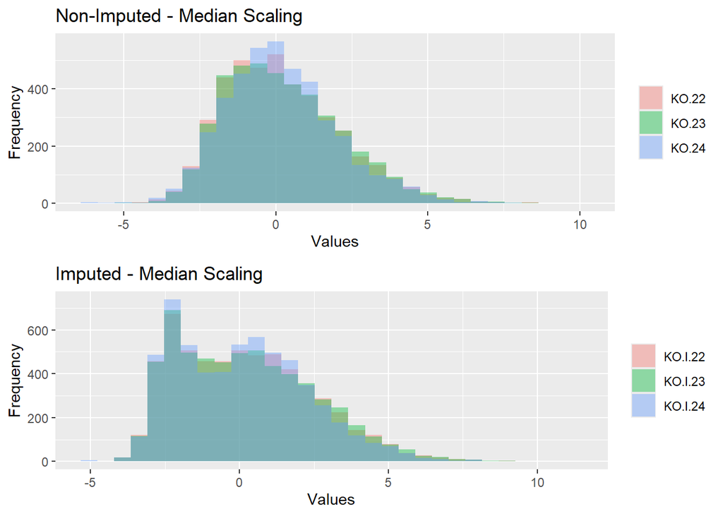

```r
moments::skewness(cbind(LFQ_KO.med,LFQ_KO_imp.med), na.rm=TRUE)
```

```
##     KO.22     KO.23     KO.24   KO.I.22   KO.I.23   KO.I.24
## 0.6754195 0.6725489 0.5218363 0.5761698 0.5868388 0.5206581
```

## MAD Scaling

```r
LFQ_KO.mad <- as.data.frame(DescTools::RobScale(LFQ_KO)) # Non-Imputed
LFQ_KO_imp.mad <- as.data.frame(DescTools::RobScale(LFQ_KO_imp)) # Imputed
```

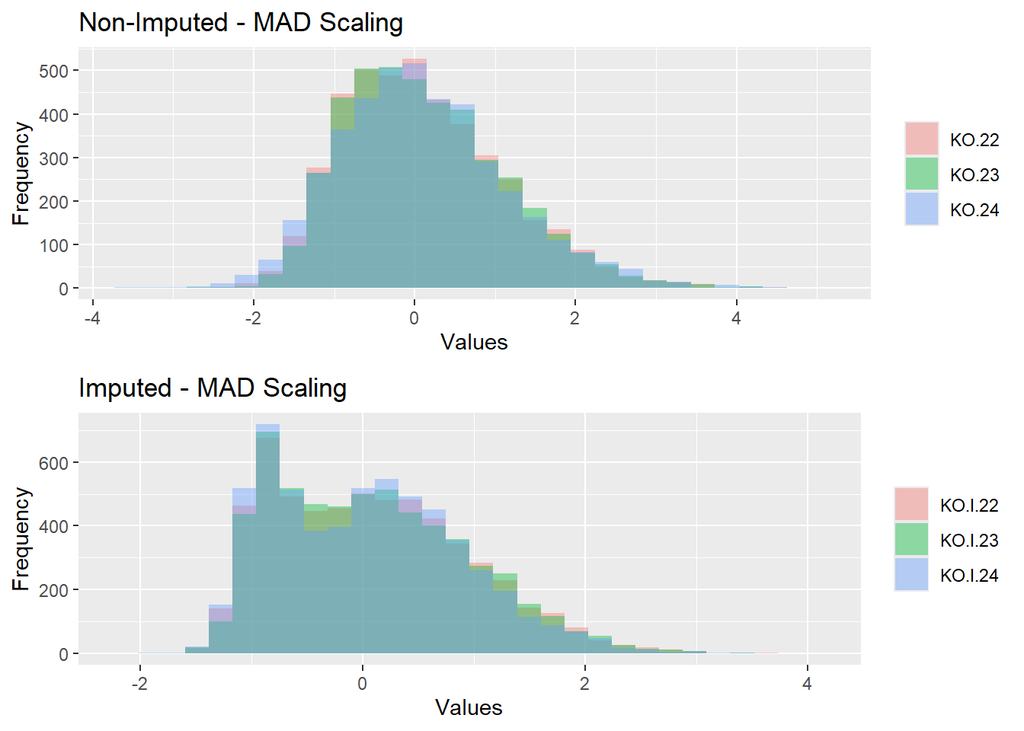

```r
moments::skewness(cbind(LFQ_KO.mad,LFQ_KO_imp.mad), na.rm=TRUE)
```

```
##     KO.22     KO.23     KO.24   KO.I.22   KO.I.23   KO.I.24
## 0.6754195 0.6725489 0.5218363 0.5761698 0.5868388 0.5206581
```

Bove Median and Mad Scaling didn’t give us the expected result.

## Linear Regression Normalization

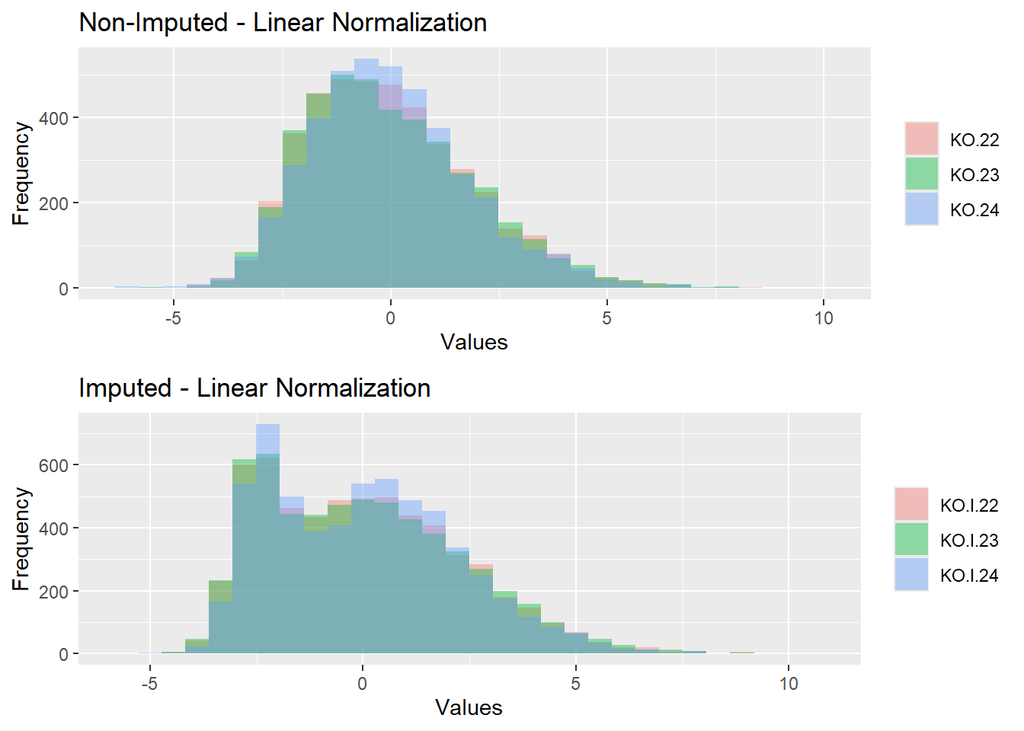

```r
moments::skewness(cbind(LFQ_KO.lm, LFQ_KO_imp.lm), na.rm=TRUE)
```

```
##     KO.22     KO.23     KO.24   KO.I.22   KO.I.23   KO.I.24
## 0.6754195 0.6725489 0.5218363 0.5761698 0.5868388 0.5206581
```

Linear Regression also didn’t give us expected result.

# Transformation - WT

Like earlier we will first use the logarithmic transformation.

## Logarithm

```r
LFQ_WT.log <- log(LFQ_WT) # Non-Imputed
LFQ_WT_imp.log <- log(LFQ_WT_imp) # Imputed
```

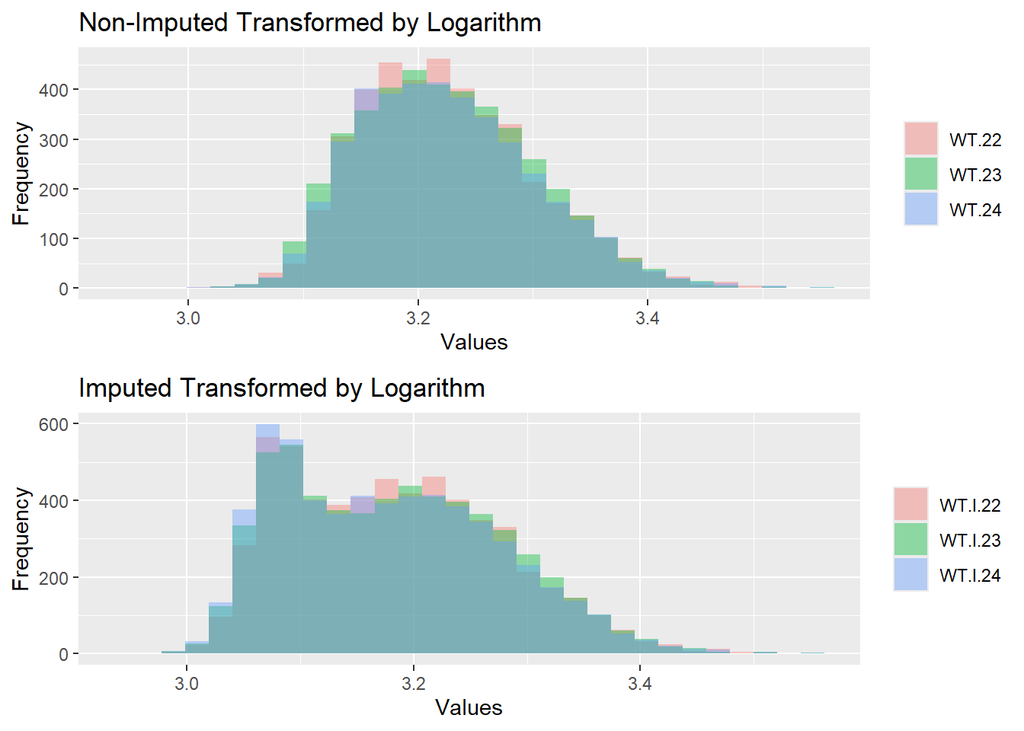

```r
moments::skewness(cbind(LFQ_WT.log, LFQ_WT_imp.log), na.rm=TRUE)
```

```
##     WT.22     WT.23     WT.24   WT.I.22   WT.I.23   WT.I.24
## 0.5066689 0.4177543 0.4800066 0.4279311 0.3823422 0.4567911
```

## Fraction $1/x$

```r
LFQ_WT.frac <- 1/LFQ_WT # Non-Imputed
LFQ_WT_imp.frac <- 1/LFQ_WT_imp # Imputed
```

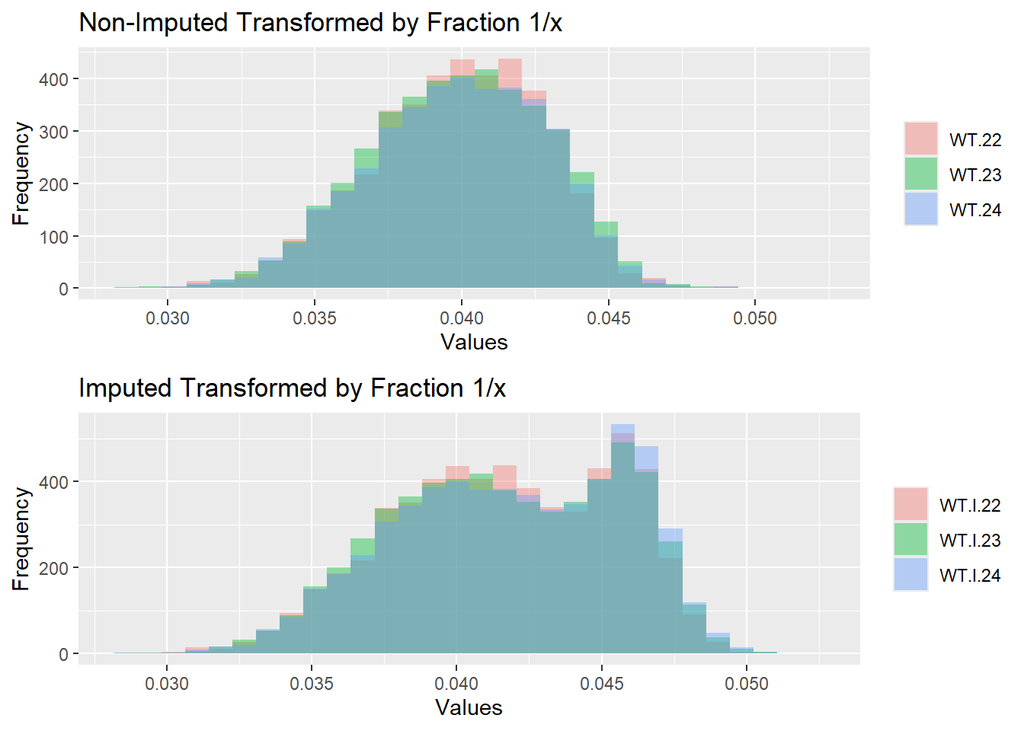

As we can see above, the results are the same like for the knockout cell type. With simple methods we can’t make the distribution closer to Gaussian dist.

## Box-Cox Transformation

The transformation is based on the formula:

$$x' = \Bigg\{
\matrix{\frac{x^{\lambda}-1}{\lambda} & \lambda \neq0 \\
log(x) & \lambda = 0}$$

```r
### Non-Imputed ###
# At first we have to calculate the lambda
lambda.22 <- car::powerTransform(LFQ_WT$WT.22)$lambda
lambda.23 <- car::powerTransform(LFQ_WT$WT.23)$lambda
lambda.24 <- car::powerTransform(LFQ_WT$WT.24)$lambda
```

|  | lambda.22 | lambda.23 | lambda.24 |
| --- | --- | --- | --- |
| lambda | -2.487442 | -2.011121 | -2.304279 |

The lambda is not 0, so the first transformation is performed.

```r
LFQ_WT.boxcox.22 <- car::bcPower(LFQ_WT$WT.22, lambda.22)
LFQ_WT.boxcox.23 <- car::bcPower(LFQ_WT$WT.23, lambda.23)
LFQ_WT.boxcox.24 <- car::bcPower(LFQ_WT$WT.24, lambda.24)
LFQ_WT.boxcox <- data.frame(LFQ_WT.boxcox.22, LFQ_WT.boxcox.23, LFQ_WT.boxcox.24)
colnames(LFQ_WT.boxcox) <- c('WT.22', 'WT.23', 'WT.24')
```

Let’s check the imputed data.

```r
### Imputed ###
# At first we have to calculate the lambda
lambda.22 <- car::powerTransform(LFQ_WT_imp$WT.I.22)$lambda
lambda.23 <- car::powerTransform(LFQ_WT_imp$WT.I.23)$lambda
lambda.24 <- car::powerTransform(LFQ_WT_imp$WT.I.24)$lambda
```

|  | lambda.22 | lambda.23 | lambda.24 |
| --- | --- | --- | --- |
| lambda | -2.15551 | -1.922671 | -2.313652 |

The lambda is not 0, so the first transformation is performed.

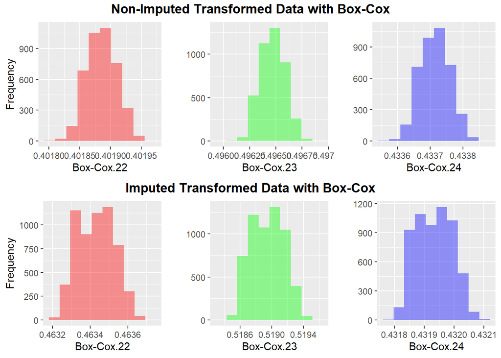

```r
LFQ_WT.boxcox.22 <- car::bcPower(LFQ_WT_imp$WT.I.22, lambda.22)
LFQ_WT.boxcox.23 <- car::bcPower(LFQ_WT_imp$WT.I.23, lambda.23)
LFQ_WT.boxcox.24 <- car::bcPower(LFQ_WT_imp$WT.I.24, lambda.24)
LFQ_WT_imp.boxcox <- data.frame(LFQ_WT.boxcox.22, LFQ_WT.boxcox.23, LFQ_WT.boxcox.24)
colnames(LFQ_WT_imp.boxcox) <- c('WT.I.22', 'WT.I.23', 'WT.I.24')
```

```r
moments::skewness(cbind(LFQ_WT.boxcox, LFQ_WT_imp.boxcox), na.rm=TRUE)
```

```
##      WT.22      WT.23      WT.24    WT.I.22    WT.I.23    WT.I.24
## 0.02095747 0.01822482 0.02082671 0.05750385 0.05404352 0.06835686
```

And again the Box-Cox Tranformation gave us expected result. The distributions are similar to a normal distribution.

# Normalization - WT

## Z-score Normalization

```r
LFQ_WT.standard <- as.data.frame(scale(LFQ_WT)) # Non-Imputed
LFQ_WT_imp.standard <- as.data.frame(scale(LFQ_WT_imp)) # Imputed
```

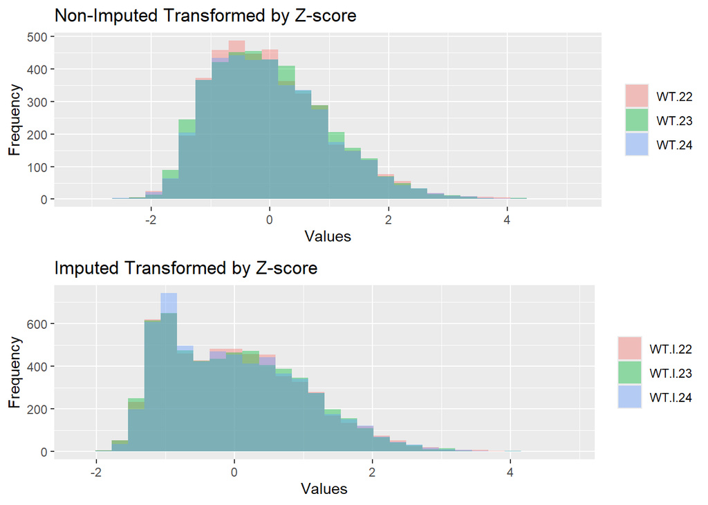

```r
moments::skewness(cbind(LFQ_WT.standard, LFQ_WT_imp.standard), na.rm=TRUE)
```

```
##     WT.22     WT.23     WT.24   WT.I.22   WT.I.23   WT.I.24
## 0.7211065 0.6383786 0.7043256 0.6285968 0.5813767 0.6579983
```

Unfortunately the standardization didn’t help to bring the distribution closer to the normal dist.

## Min-max Normalization

```r
LFQ_WT.minmax <- as.data.frame(lapply(LFQ_WT, function(col) min_max_norm(col))) # Non-Imputed
LFQ_WT_imp.minmax <- as.data.frame(lapply(LFQ_WT_imp, function(col) min_max_norm(col))) # Imputed
```

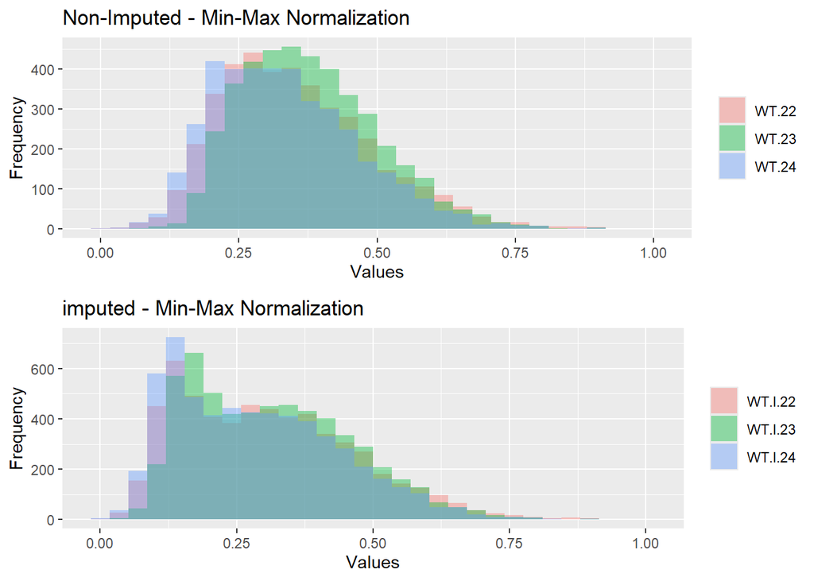

```r
moments::skewness(cbind(LFQ_WT.minmax, LFQ_WT_imp.minmax), na.rm=TRUE)
```

```
##     WT.22     WT.23     WT.24   WT.I.22   WT.I.23   WT.I.24
## 0.7211065 0.6383786 0.7043256 0.6285968 0.5813767 0.6579983
```

Unfortunately, again the normalization didn’t help. 😒

## Median Scaling

```r
LFQ_WT.med <- as.data.frame(DescTools::RobScale(LFQ_WT, scale = FALSE)) # Non-Imputed
LFQ_WT_imp.med <- as.data.frame(DescTools::RobScale(LFQ_WT_imp, scale = FALSE)) # Imputed
```

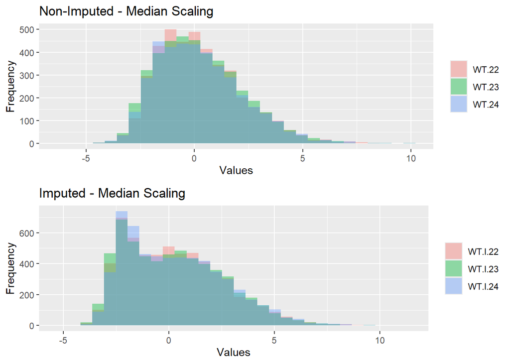

```r
moments::skewness(cbind(LFQ_WT.med,LFQ_WT_imp.med), na.rm=TRUE)
```

```
##     WT.22     WT.23     WT.24   WT.I.22   WT.I.23   WT.I.24
## 0.7211065 0.6383786 0.7043256 0.6285968 0.5813767 0.6579983
```

## MAD Scaling

```r
LFQ_WT.mad <- as.data.frame(DescTools::RobScale(LFQ_WT)) # Non-Imputed
LFQ_WT_imp.mad <- as.data.frame(DescTools::RobScale(LFQ_WT_imp)) # Imputed
```

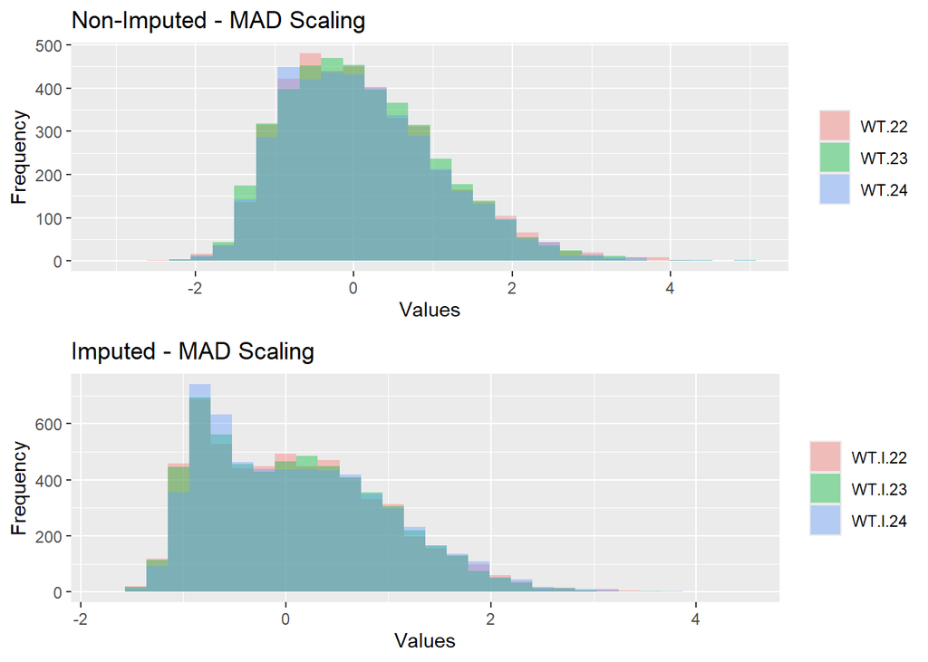

```r
moments::skewness(cbind(LFQ_WT.mad,LFQ_WT_imp.mad), na.rm=TRUE)
```

```
##     WT.22     WT.23     WT.24   WT.I.22   WT.I.23   WT.I.24
## 0.7211065 0.6383786 0.7043256 0.6285968 0.5813767 0.6579983
```

## Linear Regression Normalization

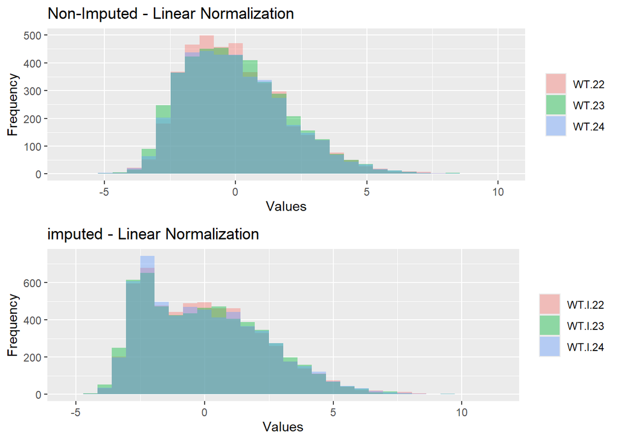

```r
moments::skewness(cbind(LFQ_WT.lm, LFQ_WT_imp.lm), na.rm=TRUE)
```

```
##     WT.22     WT.23     WT.24   WT.I.22   WT.I.23   WT.I.24
## 0.7211065 0.6383786 0.7043256 0.6285968 0.5813767 0.6579983
```

# VSN

VSN - Variance Stabilization Normalization

```r
lfq_rglist<- new('RGList', list(
    R = as.matrix(LFQ_KO),
    G = as.matrix(LFQ_WT)))

lfq_rglist_imp<- new('RGList', list(
    R = as.matrix(LFQ_KO_imp),
    G = as.matrix(LFQ_WT_imp)))

LFQ.vsn <- justvsn(lfq_rglist)@assayData  # Non-Imputed
LFQ_imp.vsn <- justvsn(lfq_rglist_imp)@assayData # Imputed
```

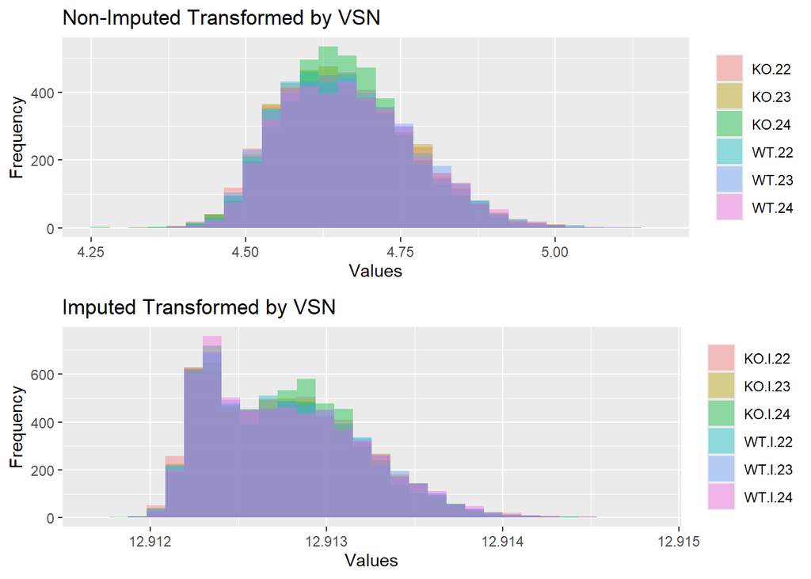

This transformation didn’t help us too. Furthermore we lost differences between knockout and wild type intensity.

```r
# Non-imputed
moments::skewness(cbind(LFQ.vsn$R, LFQ.vsn$G), na.rm=TRUE)
```

```
##     KO.22     KO.23     KO.24     WT.22     WT.23     WT.24
## 0.4488821 0.4558896 0.2747223 0.5049867 0.4228609 0.4813897
```

```r
# Imputed
moments::skewness(cbind(LFQ_imp.vsn$R, LFQ_imp.vsn$G), na.rm=TRUE)
```

```
##   KO.I.22   KO.I.23   KO.I.24   WT.I.22   WT.I.23   WT.I.24
## 0.5754457 0.5861375 0.5199840 0.6278960 0.5806866 0.6572911
```

# `bestNormalize` Package for Automatic Normalization

## KO

**Experiment 22**

```r
best.22 <- bestNormalize::bestNormalize(LFQ_KO$KO.22) # Non-Imputed
```

```r
best_imp.22 <- bestNormalize::bestNormalize(LFQ_KO_imp$KO.I.22) # Imputed
```

**Experiment 23**

```r
best.23 <- bestNormalize::bestNormalize(LFQ_KO$KO.23) # Non-Imputed
```

```r
best_imp.23 <- bestNormalize::bestNormalize(LFQ_KO_imp$KO.I.23) # Imputed
```

**Experiment 24**

```r
best.24 <- bestNormalize::bestNormalize(LFQ_KO$KO.24) # Non-Imputed
```

```r
best_imp.24 <- bestNormalize::bestNormalize(LFQ_KO_imp$KO.I.24) # Imputed
```

**Summary**

```
##           Exp_22 Exp_22_imp    Exp_23 Exp_23_imp Exp_24 Exp_24_imp
## Method orderNorm  orderNorm orderNorm  orderNorm boxcox  orderNorm
```

Based on the result for each column, the best method to normalize the data is Order Quntile Normalization for samples:

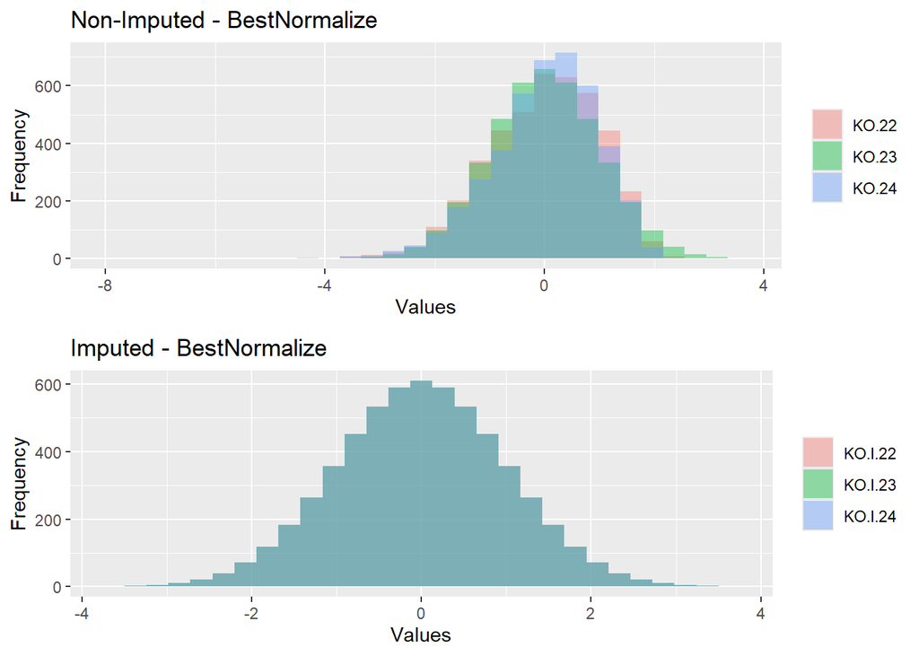

## WT

**Experiment 22**

```r
best.22 <- bestNormalize::bestNormalize(LFQ_WT$WT.22) # Non-Imputed
```

```r
best_imp.22 <- bestNormalize::bestNormalize(LFQ_WT_imp$WT.I.22) # Imputed
```

**Experiment 23**

```r
best.23 <- bestNormalize::bestNormalize(LFQ_WT$WT.23) # Non-Imputed
```

```r
best_imp.23 <- bestNormalize::bestNormalize(LFQ_WT_imp$WT.I.23) # Imputed
```

**Experiment 24**

```r
best.24 <- bestNormalize::bestNormalize(LFQ_WT$WT.24) # Non-Imputed
```

```r
best_imp.24 <- bestNormalize::bestNormalize(LFQ_WT_imp$WT.I.24) # Imputed
```

**Summary**

```
##           Exp_22 Exp_22_imp    Exp_23 Exp_23_imp    Exp_24 Exp_24_imp
## Method orderNorm  orderNorm orderNorm  orderNorm orderNorm  orderNorm
```

Like earlier the best method for each column is Order Quantile Normalization.

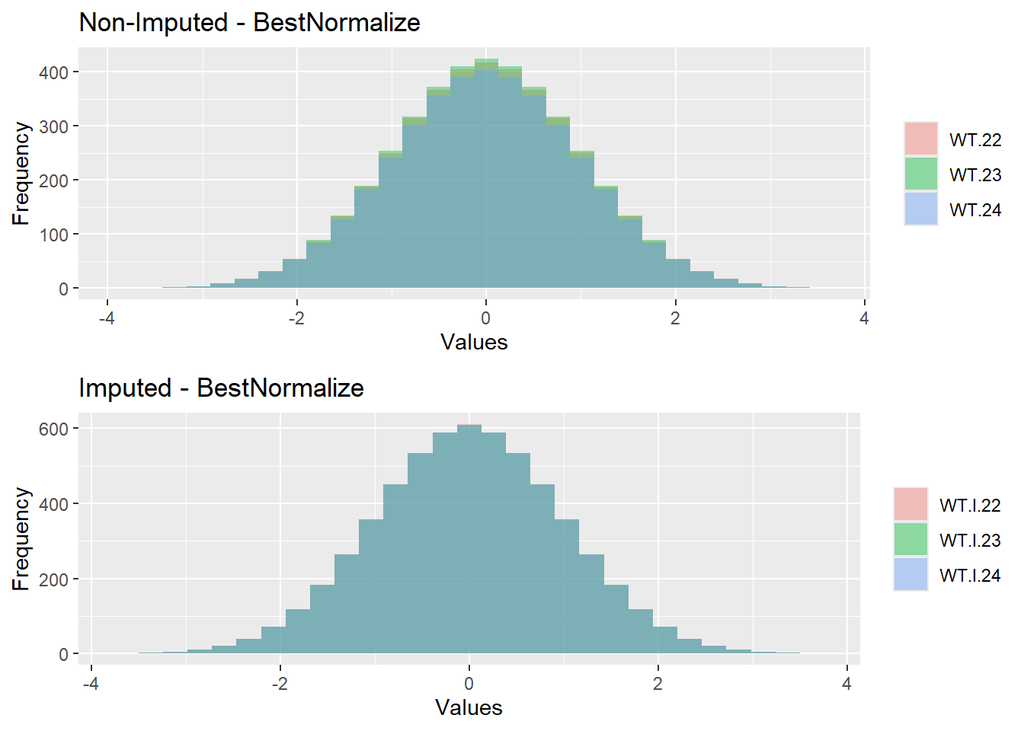

```r
moments::skewness(cbind(LFQ_WT.bestNorm, LFQ_WT_imp.bestNorm), na.rm = TRUE)
```

```
##              WT.22              WT.23              WT.24            WT.I.22
##  0.000000255971820  0.000000228105562  0.000000084736746 -0.000000003968973
##            WT.I.23            WT.I.24
## -0.000000045719609 -0.000000016718898
```

As we can see both KO and WT data have a normal distribution, but we have lost the differences between samples.

# EigenMS Non-Imputed

```r
protein.groups <- readr::read_tsv('data/proteinGroups.txt', show_col_types = FALSE)
protein.groups <- protein.groups %>% filter(is.na(`Only identified by site`),
                         is.na(Reverse),
                         is.na(`Potential contaminant`))

# I needed unique values for each peptide, so I create artificial names `prot_1:5905`
prot.info <- data.frame(protein.groups[,"Peptide sequences"], paste('prot_', 1:nrow(lfq), sep = ''))
LFQ.eig1 <- eig_norm1(lfq, treatment = as.factor(c('KO', 'KO', 'KO', 'WT', 'WT', 'WT')), prot.info = prot.info)
```

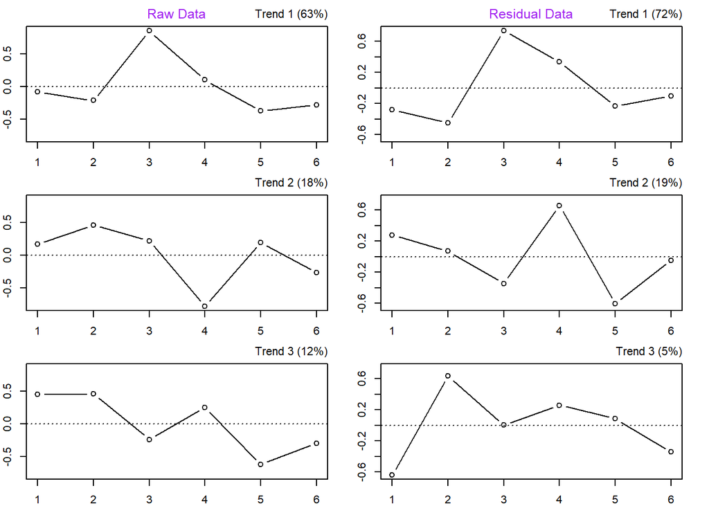

```r
# Performing eig normalization
LFQ.eig_norm <- eig_norm2(LFQ.eig1)
```

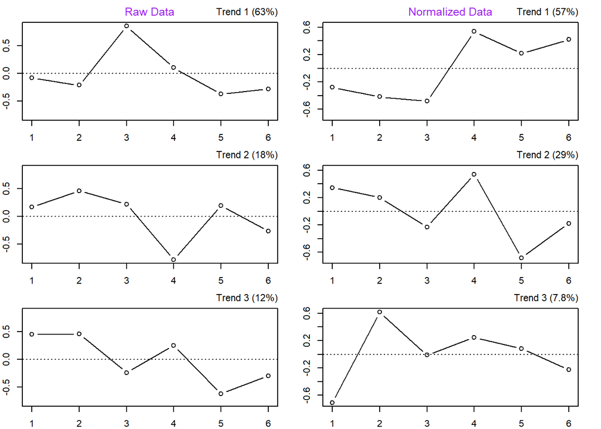

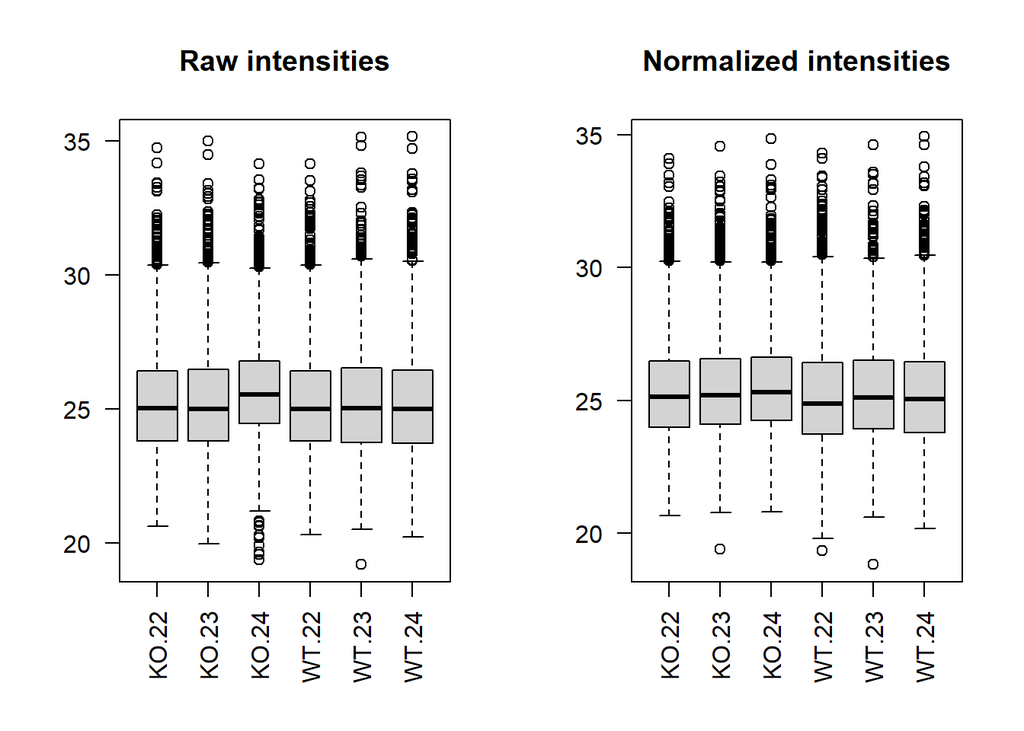

```r
par(mfcol=c(1,2))
boxplot(lfq, las=2, main='Raw intensities')
boxplot(LFQ.eig_norm$norm_m, las=2, main='Normalized intensities')
```

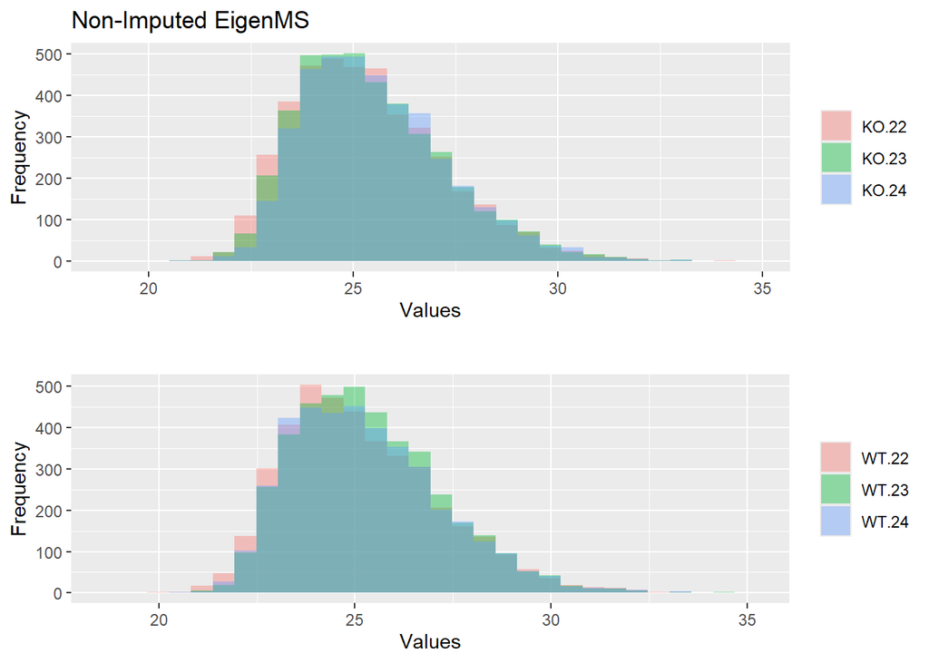

```r
ggarrange(
    plothist(LFQ.eig_norm$norm_m[,1:3], 'Non-Imputed EigenMS'),
    plothist(LFQ.eig_norm$norm_m[,4:6], ''),
    nrow=2,ncol=1
)
```

```r
moments::skewness(LFQ.eig_norm$norm_m, na.rm=TRUE)
```

```
##     KO.22     KO.23     KO.24     WT.22     WT.23     WT.24
## 0.7008182 0.7392194 0.7785731 0.7016820 0.6860371 0.7237159
```

The eigen normalization perfectly shows the differences between cell type, but distributions are skewed all the time.

# EigenMS Imputed

```r
# I needed unique values for each peptide, so I create artificial names `prot_1:5905`
prot.info <- data.frame(protein.groups[,"Peptide sequences"], paste('prot_', 1:nrow(lfq_imp), sep = ''))
LFQ_imp.eig1 <- eig_norm1(lfq_imp, treatment = as.factor(c('KO', 'KO', 'KO', 'WT', 'WT', 'WT')), prot.info = prot.info)
```

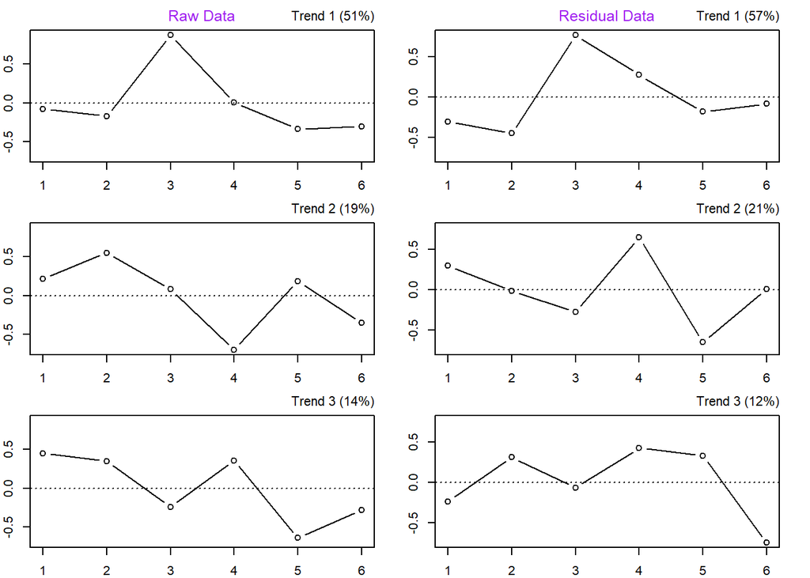

```r
# Performing eig normalization
LFQ_imp.eig_norm <- eig_norm2(LFQ_imp.eig1)
```

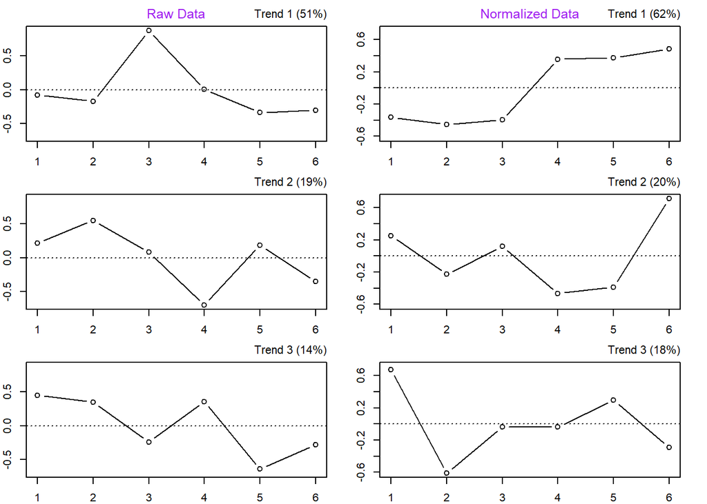

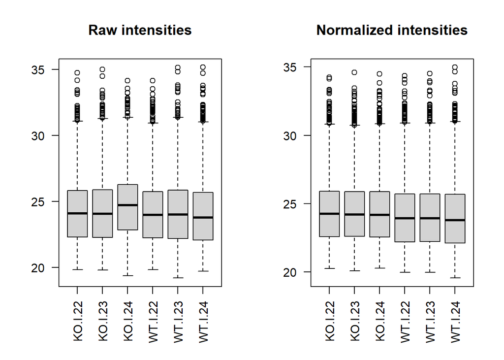

```r
par(mfcol=c(1,2))
boxplot(lfq_imp, las=2, main='Raw intensities')
boxplot(LFQ_imp.eig_norm$norm_m, las=2, main='Normalized intensities')
```

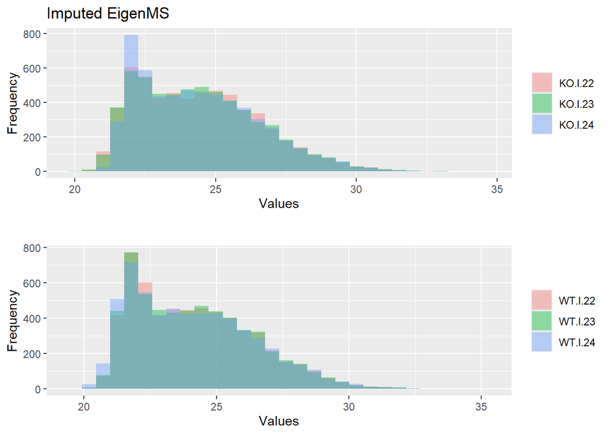

```r
ggarrange(
    plothist(LFQ_imp.eig_norm$norm_m[,1:3], 'Imputed EigenMS'),
    plothist(LFQ_imp.eig_norm$norm_m[,4:6], ''),
    nrow=2,ncol=1
)
```

```r
moments::skewness(LFQ_imp.eig_norm$norm_m, na.rm=TRUE)
```

```
##   KO.I.22   KO.I.23   KO.I.24   WT.I.22   WT.I.23   WT.I.24
## 0.6040135 0.6322023 0.6980207 0.6800863 0.6629387 0.6618507
```